[figure not shown]

# Tabular data: Univariate Numerical

Let’s load the data we previously used on schools:

```r
rm(list = ls()) # clean memory

location='https://github.com/DACSS-Visual/tabular_univar_cat/raw/main/data/'
file='eduwa.rda'
link=paste0(location,file)


#getting the data TABLE from the file in the cloud:
load(file=url(link))
```

Let me use the variable *Reduced.Lunch* which informs how many kids there are in each school that offer lunch for a reduced price. We have more than 2000 schools, so it is unlikely we find few different values. This is how many different values we have:

```r
# how many unique values
length(unique(eduwa$Reduced.Lunch))
```

```
## [1] 172
```

These are too many different values. Then, the bar plot is not a good idea (and neither a frequency table), as the bar plot produces a bar for *each* unique value in the data. This is how a bar plot will look for this variable:

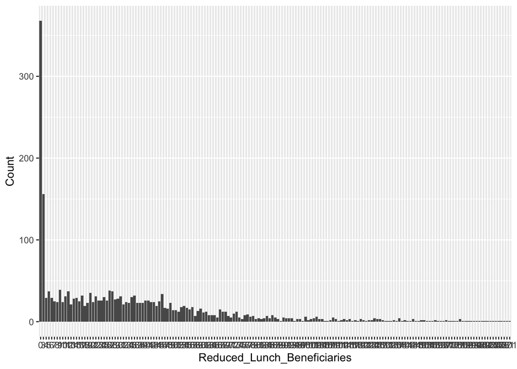

```r
# from table to dataframe
lunchDF=as.data.frame(table(eduwa$Reduced.Lunch))
names(lunchDF)=c("Reduced_Lunch_Beneficiaries","Count")

# plotting from data frame
library(ggplot2)
base1=ggplot(data=lunchDF, aes(x=Reduced_Lunch_Beneficiaries,Count))
bar1_bad=base1+geom_bar(stat = "identity")
bar1_bad
```

The variety of numerical data requires statistical exploration with some questions in mind:

- What is the representative value? Generally the **mean**, or **median**.
- How good is the representative value? You need some measure of dispersion. For the mean you have the **standard deviation** and **coefficient of variation**, and for the median the **median absolute deviation**.
- Does the shape of the distribution differs from a *normal* distribution? If there is **asymmetry**, is it large enough to show **outliers**? You need some measure of symmetry and shape (a.k.a. *kurtosis*).

First, let’s take a look at the basic statistical information:

```r
summary(eduwa$Reduced.Lunch)
```

```
##    Min. 1st Qu.  Median    Mean 3rd Qu.    Max.    NA's
##    0.00    5.00   25.50   33.53   47.00  301.00     131
```

This information may give us a general idea on how the data on *reduced lunch* is behaving, so we select the plot that highlights that behavior. Let me try a box plot:

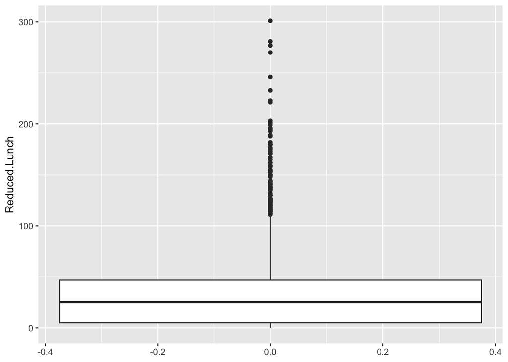

```r
base= ggplot(eduwa,aes(y = Reduced.Lunch))  #var to plot in 'y'
base + geom_boxplot()
```

That is our starting point. Now, let’s follow some steps to change the previous boxplot:

1. What should the y-axis show?

```r
# get all the summary values but the count of NAs.
(statVals=summary(eduwa$Reduced.Lunch,digits = 3)[1:6])
```

```
##    Min. 1st Qu.  Median    Mean 3rd Qu.    Max.
##     0.0     5.0    25.5    33.5    47.0   301.0
```

Instead of the default values, we could put those values in the boxplot y-axis:

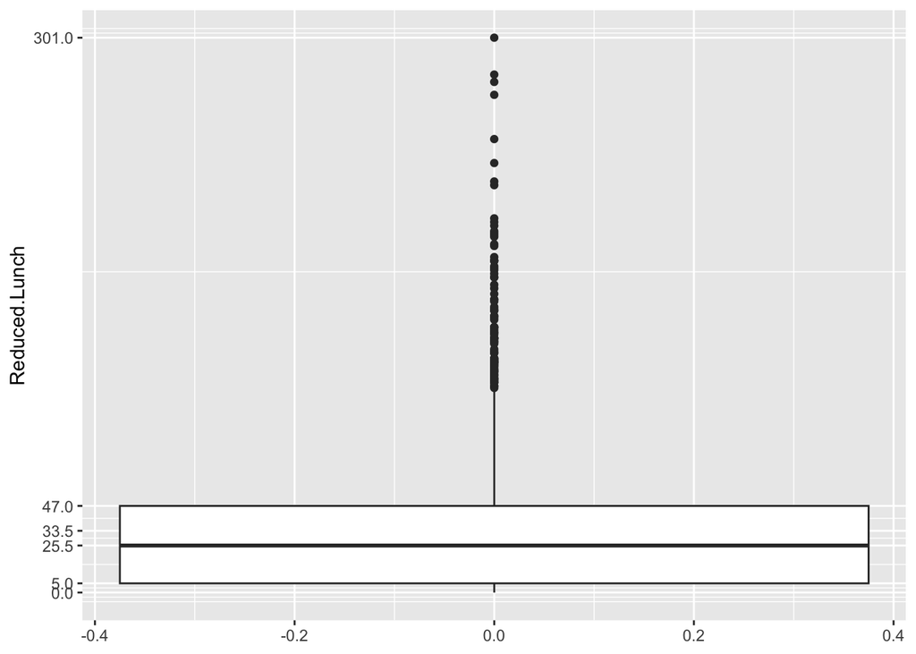

```r
library(magrittr)
# the summary values as vector
statVals=statVals%>%as.vector() #notice '%>%'

#plotting
base= ggplot(eduwa,aes(y = Reduced.Lunch))
b1= base + geom_boxplot()
b1=b1+ scale_y_continuous(breaks = statVals) #custom breaks
b1
```

In general, flipping can help:

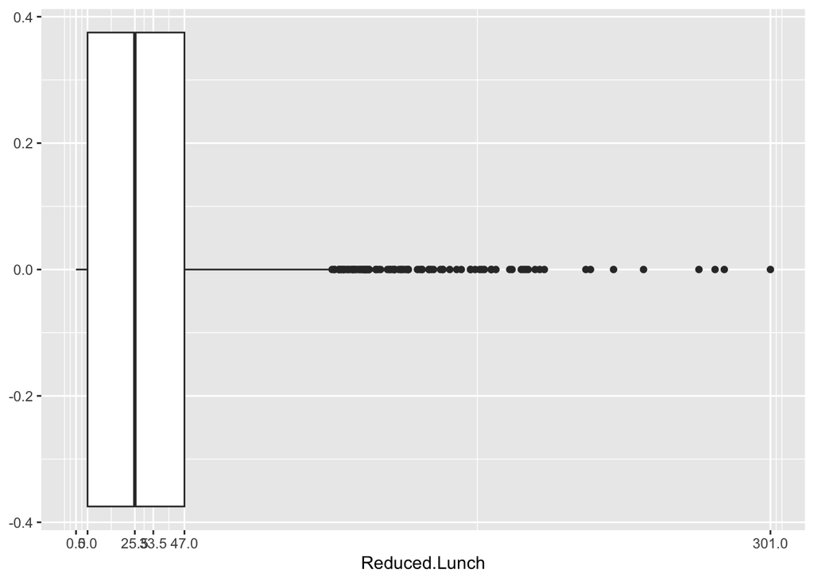

```r
b1=b1 +coord_flip()
b1
```

3. Should we annotate?

What about: * The upper limit (before outliers appear). * The amount of outliers limit (before outliers appear).

We get the upper limit like this:

```r
(upperT=ggplot_build(b1)$data[[1]]$ymax)
```

```
## [1] 110
```

We can compute the *amount of outliers* on the right tail like this:

```r
(numOutliers=sum(eduwa$Reduced.Lunch>upperT,na.rm = T))
```

```
## [1] 96
```

Let’s annotate

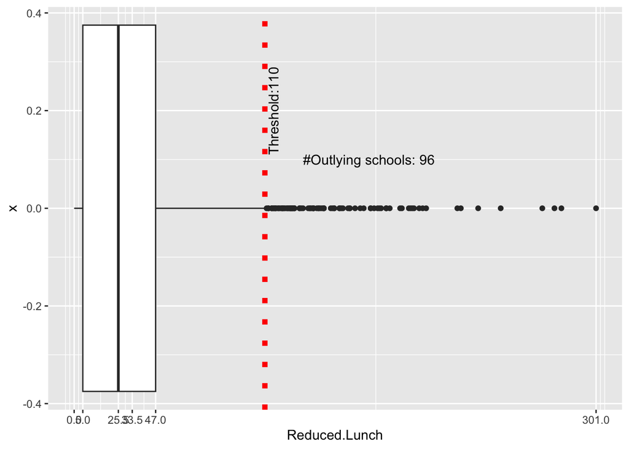

```r
# text for annotations
txtOutliers=paste0('#Outlying schools: ',numOutliers)
txtUpper=paste0('Threshold:',upperT)


b1_vertical = b1 + geom_hline(yintercept = upperT,
                            color='red',
                            linetype="dotted",
                            size=2)
b1_annot=b1_vertical + annotate(geom = 'text',
                                label=txtUpper,
                                y = upperT+5,
                                x=0.2,
                                angle=90) # text angle

b1_annot=b1_annot + annotate(geom = 'text',
                                label=txtOutliers,
                                y = upperT+60,
                                x=0.1,
                                angle=0)
b1_annot
```

3. Do we need the values in the vertical axis?

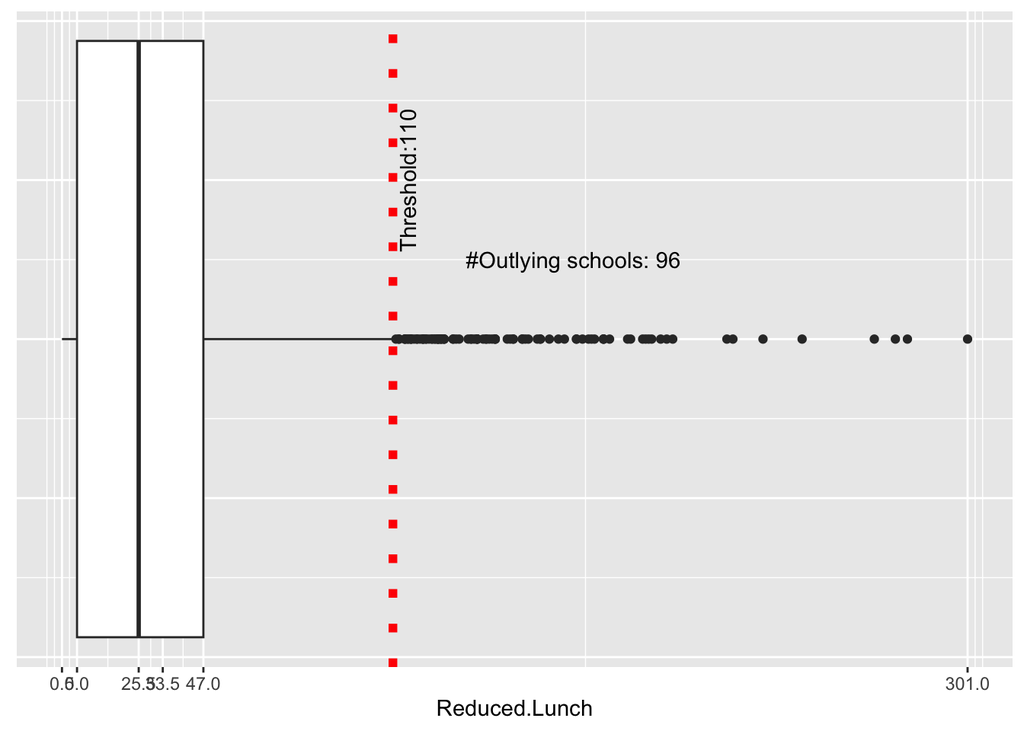

```r
b1_annot_noX = b1_annot +
                theme(axis.text.y = element_blank(),
                      axis.ticks.y = element_blank(),
                      axis.title.y = element_blank())
b1_annot_noX
```

4. What may need further changes?
- What about choosing a different theme (grid)?

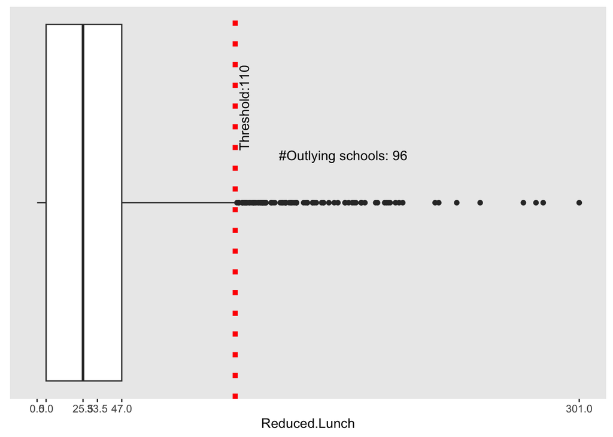

```r
b1_newGrid=b1_annot_noX +  theme(panel.grid = element_blank())
b1_newGrid
```

- Maybe the text in the horizontal is not easy to read yet?

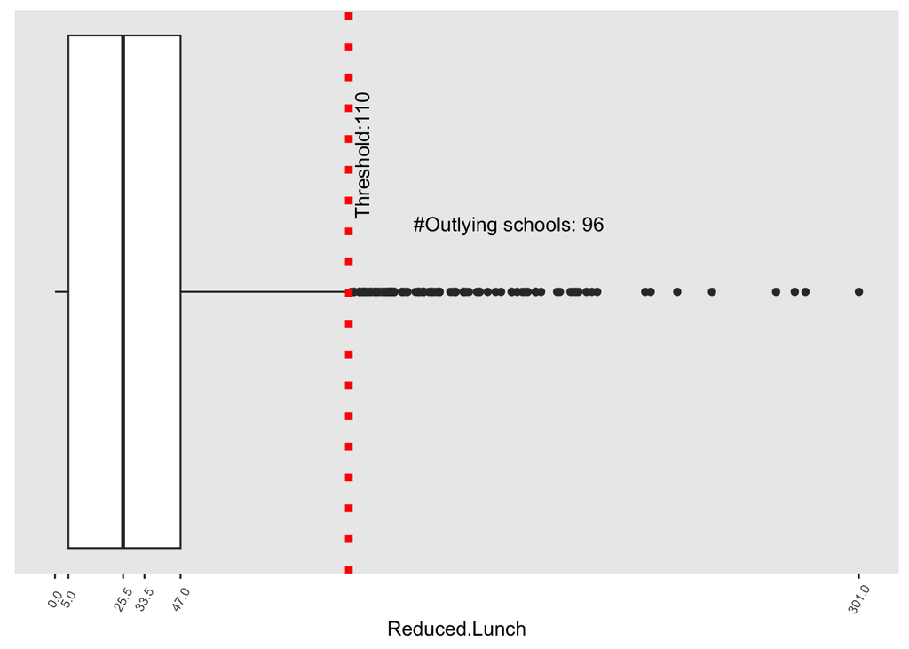

```r
b1_newGrid_axisText = b1_newGrid+ theme(axis.text.x = element_text(angle = 60,
                                                                  size = 7,
                                                                  vjust = 0.5))
b1_newGrid_axisText
```

In general, numerical data are prone to have outliers in real life (it is not common to speak about outliers in ordinal data since they have few levels).

The **summary** command can be supplemented with some measures of spread or dispersion:

```r
# standard deviation:
sd(eduwa$Reduced.Lunch,na.rm = T)
```

```
## [1] 36.55684
```

```r
# median absolute deviation:
mad(eduwa$Reduced.Lunch,na.rm = T)
```

```
## [1] 30.3933
```

```r
# coefficient of variation
library(DescTools)
CoefVar(eduwa$Reduced.Lunch,
        na.rm = T)
```

```
## [1] 1.090129
```

There are also measures of shape:

```r
# asymmetry
Skew(eduwa$Reduced.Lunch,
     na.rm = T)
```

```
## [1] 2.158124
```

```r
# kurtosis
Kurt(eduwa$Reduced.Lunch,
     na.rm = T)
```

```
## [1] 7.311024
```

And the confidence interval for the mean:

```r
# confidence interval for the mean
MeanCI(eduwa$Reduced.Lunch,
     na.rm = T)
```

```
##     mean   lwr.ci   upr.ci
## 33.53441 32.03831 35.03051
```

*What do we know right now?*

1. The data is skewed, with a right tail.
2. The data is concentrated in a small group of values.
3. In this situation, the median is more informative than the mean.

You can save those values for future annotations:

```r
cv=CoefVar(eduwa$Reduced.Lunch,na.rm = T)
sd=SD(eduwa$Reduced.Lunch,na.rm = T)
md=Median(eduwa$Reduced.Lunch,na.rm = T)
mn=Mean(eduwa$Reduced.Lunch,na.rm = T)
mn.low=MeanCI(eduwa$Reduced.Lunch,
     na.rm = T)[['lwr.ci']]
mn.up=MeanCI(eduwa$Reduced.Lunch,
     na.rm = T)[['upr.ci']]
sk=Skew(eduwa$Reduced.Lunch,
     na.rm = T)
```

A key visual for numerical data is the **histogram**. The histogram looks like a bar plot. In both cases the height of the bars represent counts/percents, but the bars in the histogram are consecutive while the bases of the bars are numeric intervals (**binwidth** informs the width of the intervals). Histograms mainly help you see clearly where and how many *peaks* there are in the data distribution. Let’s make one:

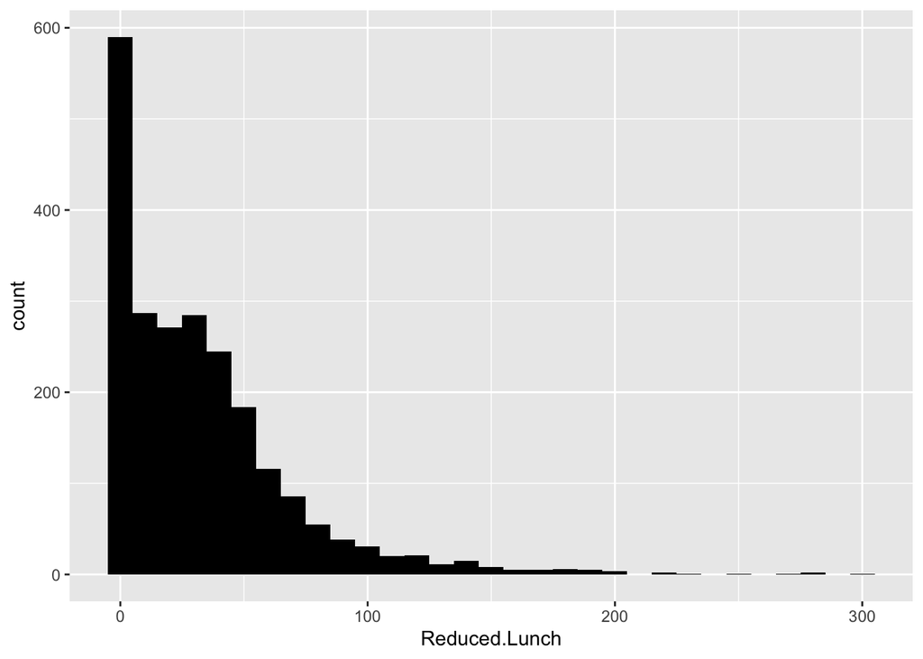

```r
#ggplot
barWIDTH=10
library(ggplot2)
base= ggplot(eduwa)
h1= base + geom_histogram(aes(x = Reduced.Lunch),
                          binwidth = barWIDTH,
                          fill='black')
h1=h1 + labs(y="count")
h1
```

Let’s do some annotations:

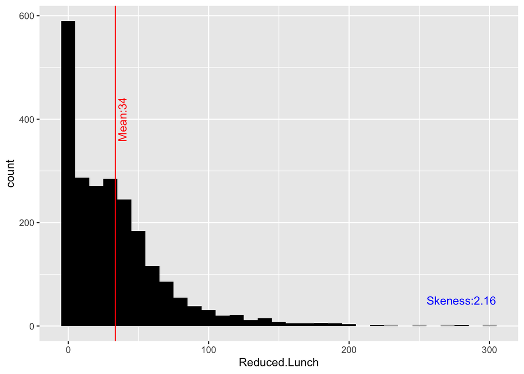

```r
# texts
txtMean=paste0('Mean:',round(mn))
txtSkew=paste0('Skeness:',round(sk,2))

# adding
h1_ann=h1+ geom_vline(xintercept = mn,color='red') + # mean as line
    # about the mean
    annotate(geom = 'text',color='red',
             label=txtMean, # mean as text
              y = 400,
              x=mn+5,
              angle=90) +
    # about the skewness
    annotate(geom = 'text', color='blue',
             label=txtSkew, # skewness as text
              y = 50,
              x=upperT+170,
              angle=0)

h1_ann
```

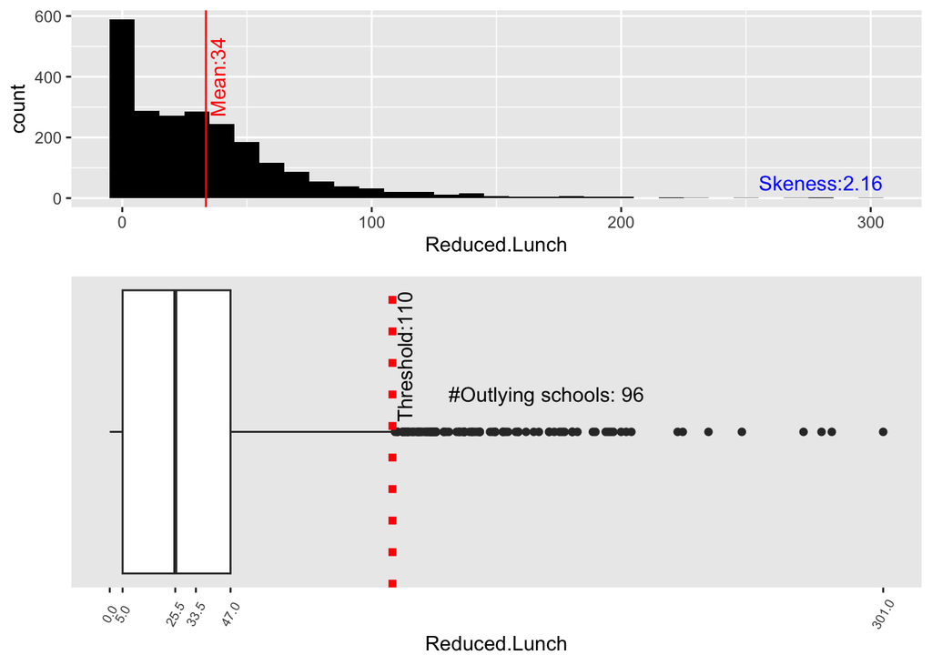

```r
library(ggpubr)
ggarrange(h1_ann,b1_newGrid_axisText,align='v',ncol = 1,heights = 2:4)
```

As you see, that is not an exact match. An alternative can be the **violin** plot.

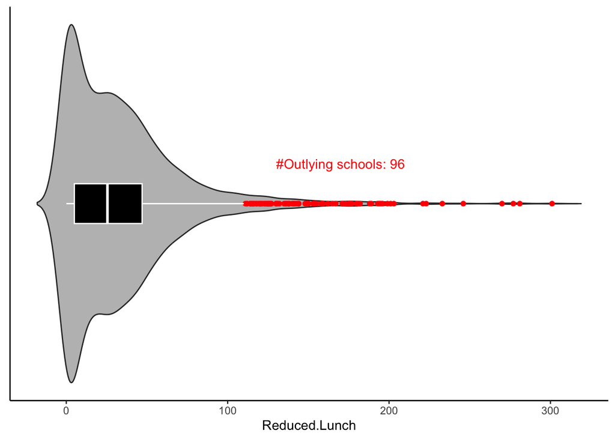

```r
base=ggplot(eduwa, aes(x=0,y=Reduced.Lunch))+
            theme_classic()

vio=base+geom_violin(trim=FALSE, fill="grey")

viobox=vio+geom_boxplot(width=0.1,outlier.color = 'red',colour = 'white',fill='black')
viobox=viobox + coord_flip() +
                theme(axis.text.y = element_blank(),
                      axis.ticks.y = element_blank(),
                      axis.title.y = element_blank()) + annotate(geom = 'text',
                                label=txtOutliers,
                                y = upperT+60,
                                x=0.1,color='red',
                                angle=0)
viobox
```

The violin plot will inform the presence of peaks, but not on the maximum value of the peak as the histogram shows.

Go to top of document.

# First Deliverable (Option 2)

- **Alternative 1**: Prepare a plot for the column **Student.Teacher.Ratio**.
- **Alternative 2** (more challenging!): Aggregate *Reduced.Lunch* by summing up per County, so that you can prepare a Pareto visual:

```r
reducedLunch_county=aggregate(data=eduwa,
                              Reduced.Lunch~County,
                              FUN=sum)
reducedLunch_county
```

```
##          County Reduced.Lunch
## 1         Adams           634
## 2        Asotin           329
## 3        Benton          2412
## 4        Chelan          1046
## 5       Clallam          1096
## 6         Clark          6388
## 7      Columbia            53
## 8       Cowlitz          1201
## 9       Douglas           599
## 10        Ferry           120
## 11     Franklin          1592
## 12     Garfield            42
## 13        Grant          1551
## 14 Grays Harbor           510
```

[output cut: 25 more lines]

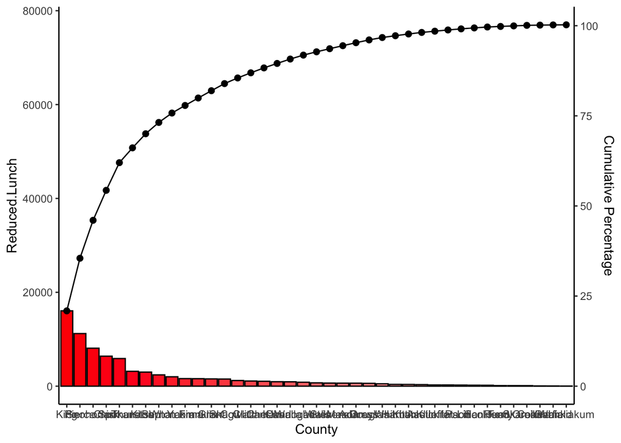

```r
library(ggQC) # install this previously

base=ggplot(data=reducedLunch_county,
             aes(x=County,y=Reduced.Lunch)) + # just the counts
     theme_classic()
paretoDraft=base + stat_pareto()
paretoDraft
```

You job is to create this plot step by step without using the **ggQC** library.

Go to top of document.